# Estimation and Hypotheses

## Estimation and hypotheses

1. Parameter (point) estimation
   - Given a model, with unknown parameters (\(\theta_0\), \(\theta_1\), …, \(\theta_k\)), how to estimate values of those parameters?
2. Interval estimation
   - How to quantify the uncertainty associated with parameter estimates?
3. Hypothesis testing
   - How to test hypotheses about parameter estimates?

## Example: Is normal body temperature 98.6 F?

Resting body temperature for a sample of healthy humans (*n* = 25):

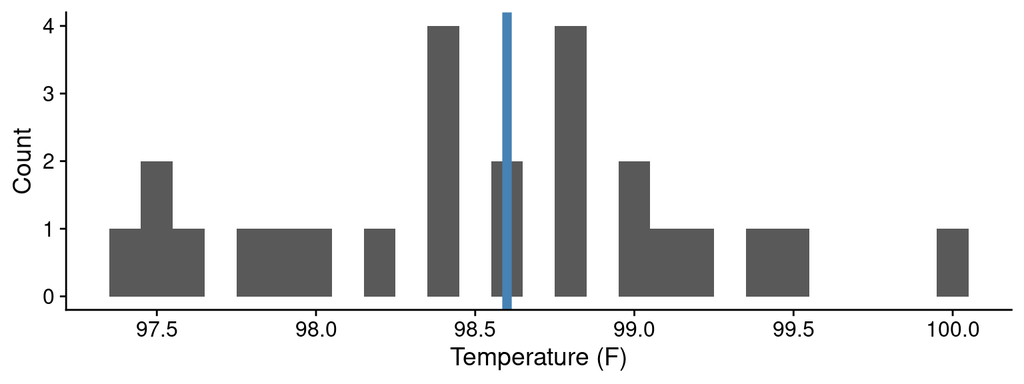

## Example: Wing Dimorphic Crickets

> Do long-winged crickets have a higher resting metabolic rate than short-winged crickets?

[figure not shown]

Controlling for body mass,

- Metabolic rates do not differ
- Average metabolic rate of long-wings is higher
- Average metabolic rate of long-wings is lower

## Example: Genetics of Corn Oil Content

> Which set of loci best predicts oil content in corn kernels?

[figure not shown]

- Heritability of corn oil content is 0
- Different possible combinations of SNPs
- All additive
- Dominance
- Epistasis
- Structural variants

## Example: Species Richness in Lakes

> Does the number of phytoplankton species change with agricultural intensity around lakes?

[figure not shown]

- There is no relationship between species richness and agricultural intensity
- There is a positive relationship
- There is a negative relationship

## Horned lizard predation

[figure not shown]

## Horned lizard predation

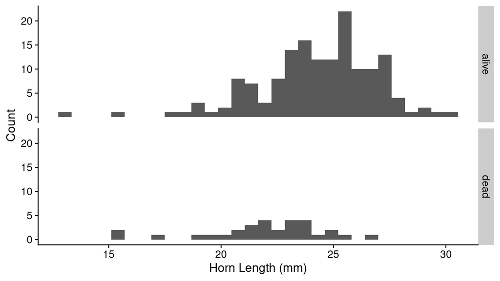

## Estimation

1. Parameter (point) estimation
   - What are the estimates for mean horn length in live and dead horned lizards?
2. Interval estimation
   - What are the confidence intervals around those estimates?
3. Hypothesis testing
   - Is a difference that large likely to happen by chance alone?

## 1. Estimate of group means

```r
HL %>% group_by(group) %>%
  summarize(horn_mean = mean(horn_length),
            horn_SEM = sd(horn_length) / length(horn_length))
```

```
## # A tibble: 2 x 3
##   group horn_mean horn_SEM
## * <chr>     <dbl>    <dbl>
## 1 alive      24.3   0.0171
## 2 dead       22.0   0.0903
```

## 3a. *t*-test for equality of means

```r
t.test(horn_length ~ group, data = HL, var.equal = TRUE)
```

```
##
##  Two Sample t-test
##
## data:  horn_length by group
## t = 4.3494, df = 182, p-value = 2.27e-05
## alternative hypothesis: true difference in means is not equal to 0
## 95 percent confidence interval:
##  1.253602 3.335402
## sample estimates:
## mean in group alive  mean in group dead
##            24.28117            21.98667
```

## 3b. Linear model for equality of means

```r
fm <- lm(horn_length ~ group, data = HL)
summary(fm)
```

```
##
## Call:
## lm(formula = horn_length ~ group, data = HL)
##
## Residuals:
##      Min       1Q   Median       3Q      Max
## -11.1812  -1.2812   0.2688   1.7188   6.0188
##
## Coefficients:
##             Estimate Std. Error t value Pr(>|t|)
## (Intercept)  24.2812     0.2130 113.987  < 2e-16 ***
## groupdead    -2.2945     0.5275  -4.349 2.27e-05 ***
## ---
## Signif. codes:  0 '***' 0.001 '**' 0.01 '*' 0.05 '.' 0.1 ' ' 1
##
## Residual standard error: 2.643 on 182 degrees of freedom
## Multiple R-squared:  0.09415,    Adjusted R-squared:  0.08918
## F-statistic: 18.92 on 1 and 182 DF,  p-value: 2.27e-05
```

Each line contains a hypothesis test of estimate = 0.